# Final Project: Suicide Rate of US States: Why Are They So Different?

Mikhail Groysman

December 3, 2018

# 1 Motivation

A few days ago, CDC released mortality data for 2017. Life expectancy has dropped for three years in a row. One of the main causes is an increase in suicide rates. Suicide keeps increasing every year for the past 2 decades and it is hard to pinpoint the exact reasons. One of the main paradoxes is a big difference in suicide rates across the country. The suicide rate for 2017 varies from 6.6 in DC to 28.9 in Montana, which is almost 4.5 times greater. Please note that the rate is age adjusted, so age distribution should not play the role. Why would a person in Montana be 4.5 times more likely to commit suicide than one in DC? If we could answer the following question, there is a greater possibility to reduce suicide rates and prevent such tragedies across our country. To illustrate that suicide is not remote and could only happen to someone unstable and weak, I would like to reference a tragedy that took place while I was working on the project: Top US Navy Admiral on active duty committed suicide(Martin 2018) only 58 years old.

# 2 Desired Outcome

At the end of this project, I expect to come with a list of variables responsible for varying suicide rates across of the states. As mentioned above, I believe that understanding factors behind the variance will help us address the ever-worsening problem of suicide across the country. To come up with answers, I will try to apply both supervised and unsupervised methods, but a primary final goal is to come with a supervised model. Final measure to evaluate our model will be Adjusted R squire.

To cluster states would also be interesting since we can see whether geography plays a role.

# 3 Current Knowledge on the Subject

We know that gender, age, mental health, substance abuse, viability of guns, and ethnicity play a major role in suicide rates. Other possible factors include but are not limited to altitude, population density, rural status, and specific occupations.

# 4 Data Sources

I researched multiple sources and none of them have any raw, detailed data because suicide is a sensitive topic for families; therefore, the government protects the families’ privacy and does not provide individual data for each case; even grouped data is often masked. This is one of the limitations I had to deal with. It was disappointing not to have all the details, but I understand that in the real world, data is not always easily and readily available.

After reviewing multiple sources of potential data, I have chosen two that seem to give me the most insight on the topic:

1. CDC WONDER, Detailed Mortality. The Mortality Database maintained by CDC(CDC 2018).
2. SAMHSA 2016-2017 State Prevalence Estimates. State level data on drug use, mental illness, and suicide attempts(SAMHSA 2018).

I have also pulled an additional Wikipedia source for comparison study:

3. Wikipedia. Table: Suicides per 100,000 people in 2016 (age standardized). WHO(Wikipedia 2018).

```r
library(readr)

library(stringr)

library(dplyr)

library(tidyr)

library(car)

library(ggplot2)

library(usmap)

library(readxl)

library(ggthemes)

library(XML)

library(RCurl)

library(ggpubr)

library(knitr)

library(kableExtra)

library(factoextra)

library(NbClust)
```

# 5 Tidying my data

## 5.1 CDC Wonder, Underlying Cause of Death, 1999-2017

This is probably as good as it gets when it comes to suicide statistics. It does not have individual records and results with values under 11 are masked (fewer than 11 deaths). However, I am not aware of better alternatives to pull suicide data. From what I have seen, CDC is the main source of data for suicide reporting.

Please note that CDC Wonder does have API; however, it does not allow to pull state level data from API.

I will pull multiple data requests from the system. I have tried to create my own master data file in one pull; however, it did not work for the following reasons:

1. If data from 2017 is used, it would have a lot of masked results. Expanding the time frame to other years, an issue of data not being up-to data, or current, rises.
2. Not enough fields can be pulled out by Wonder Query, which were needed for the project. The query only allows you to pull 6 categorical variables, while the prospected goal was all 8 of them.

### 5.1.1 2017 Suicide Data by State

The first query was Suicide Data by state for year 2017. Data was not limited in any way except for the year (2017) and cause of death (suicide).

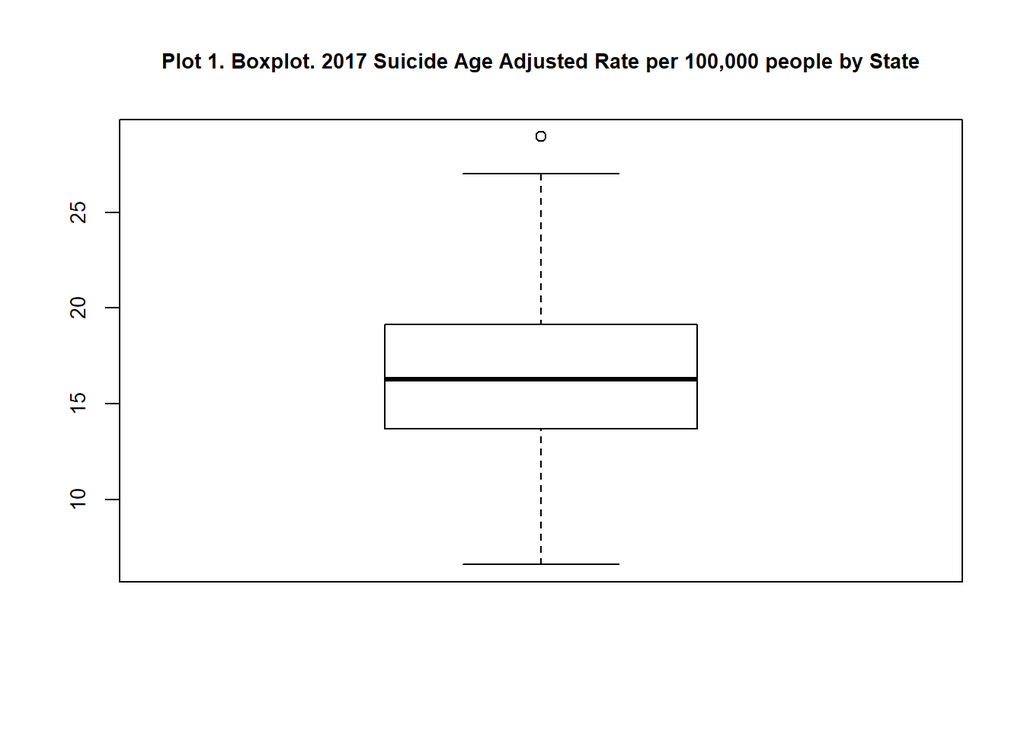

```r
state2017<-read.table("C:/Final Project/Underlying Cause of Death, 2017 Suicide State All Race All Ages.txt", header =TRUE, sep = "\t")

state2017$state<-state2017$State

state2017$AARate<-state2017$Age.Adjusted.Rate

arrange(state2017, AARate)

state2017$group1<-"US States"

par(ps = 10, cex = 1, cex.main = 1)

boxplot(state2017$AARate)

title(main="Plot 1. Boxplot. 2017 Suicide Age Adjusted Rate per 100,000 people by State")
```

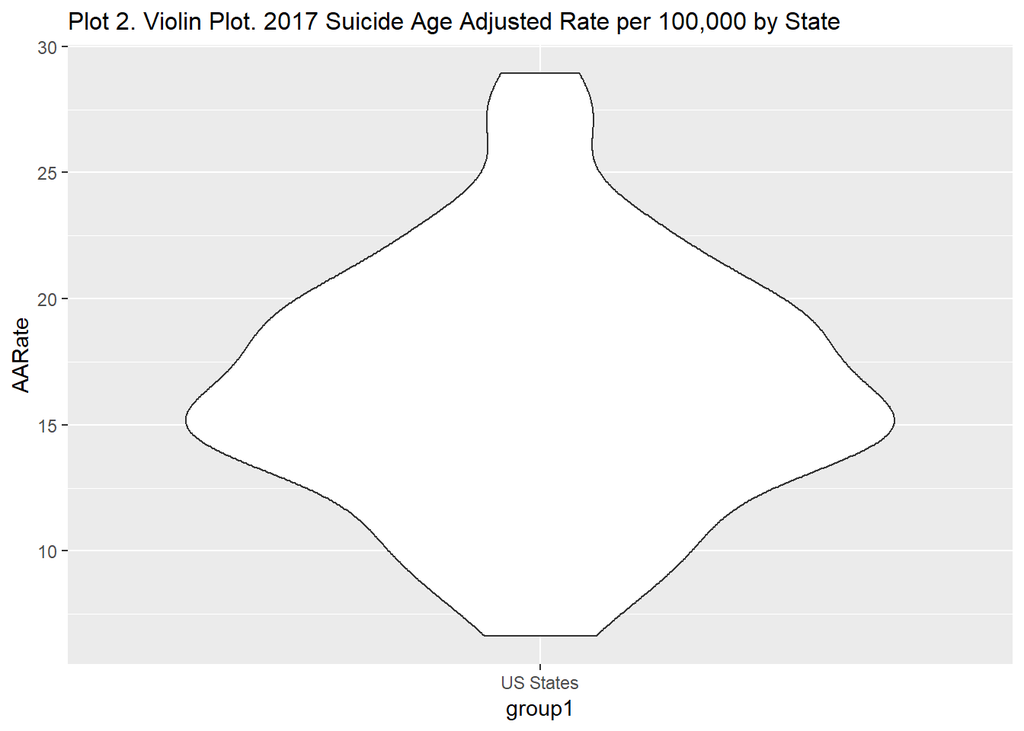

```r
ggplot(state2017, aes(x=group1, y=AARate))+geom_violin()+ggtitle("Plot 2. Violin Plot. 2017 Suicide Age Adjusted Rate per 100,000 by State")+theme(plot.title = element_text(size=12))
```

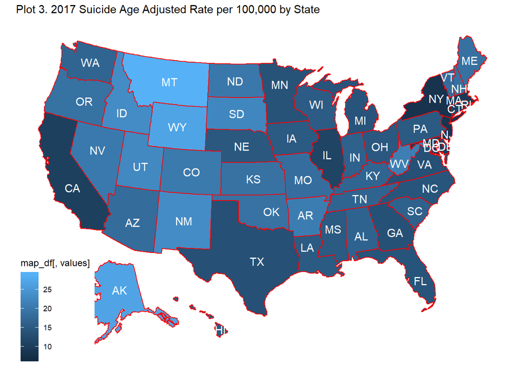

```r
plot_usmap(data = state2017, values = "AARate", theme = theme_map(), labels = TRUE, label_color = "white", lines = "red")+
  labs(title = "Plot 3. 2017 Suicide Age Adjusted Rate per 100,000 by State")
```

Montana has the highest rate, DC has the lowest. Montana seems to be an outlier.

### 5.1.2 2017 Suicide Data by State, Gender, Age 15+ Only (To get closer to SAMHA’s age of 18+)

The second query used was 2017 Suicide Data comparing state and gender. Data was limited to one year (2017), cause of death (suicide), and age (15+). Please note that we encountered unreliable data according to CDC. The data is not big enough to be considered reliable for females in DC and Delaware. For simplicity we will use the actual rate for these states. The number we use here is not for our final analysis, so we can get away with some “cheating”. If we really feel that including these 2 states will significantly skew our data (I do not feel that way), then we have 2 solutions to the problem: one is to drop these 2 states from our analysis, or pull a few more years of data, instead of using just 2017.

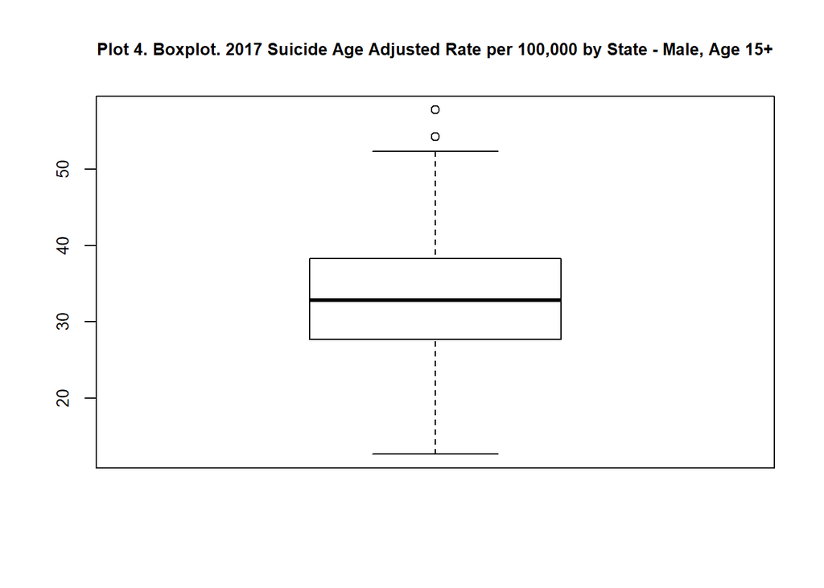

```r
state2017GA<-read.table("C:/Final Project/Underlying Cause of Death, 2017Suicide State Gender 15+.txt", header =TRUE, sep = "\t")

state2017GA$state<-state2017GA$State

state2017GA$AARate<-as.numeric(as.character(state2017GA$Age.Adjusted.Rate))

arrange(state2017GA, AARate)

state2017GA$group1<-"US States"

state2017M<-filter(state2017GA, Gender=='Male')

arrange(state2017M, AARate)

par(ps = 10, cex = 1, cex.main = 1)

boxplot(state2017M$AARate)

title(main="Plot 4. Boxplot. 2017 Suicide Age Adjusted Rate per 100,000 by State - Male, Age 15+")
```

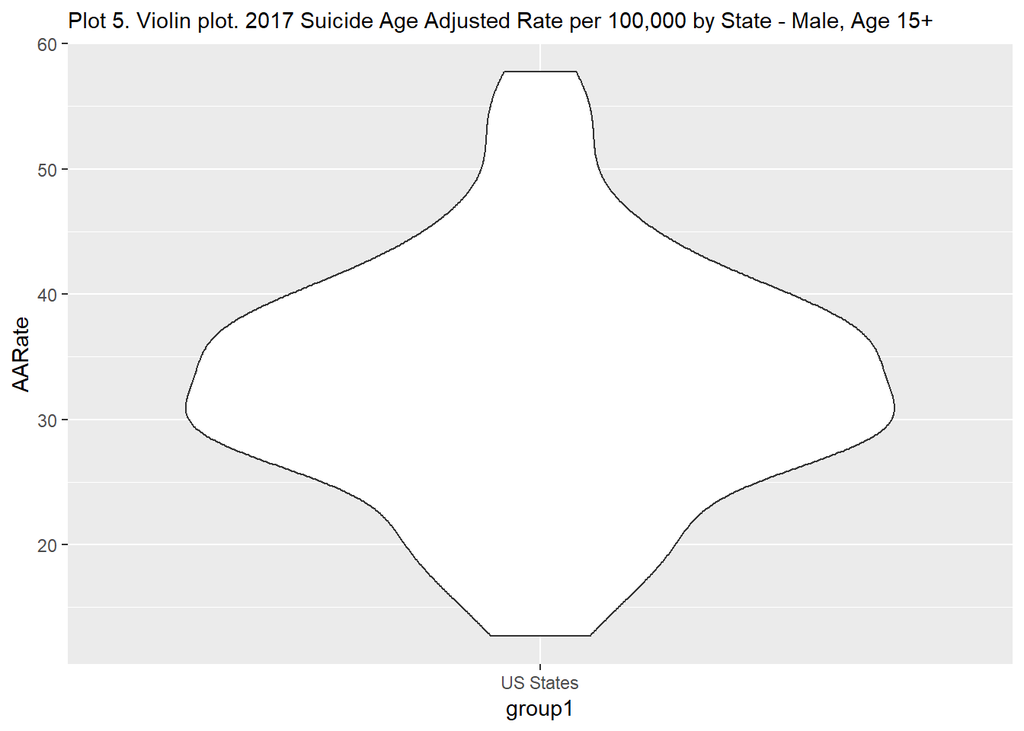

```r
ggplot(state2017M, aes(x=group1, y=AARate))+geom_violin()+ggtitle("Plot 5. Violin plot. 2017 Suicide Age Adjusted Rate per 100,000 by State - Male, Age 15+")+theme(plot.title = element_text(size=11))
```

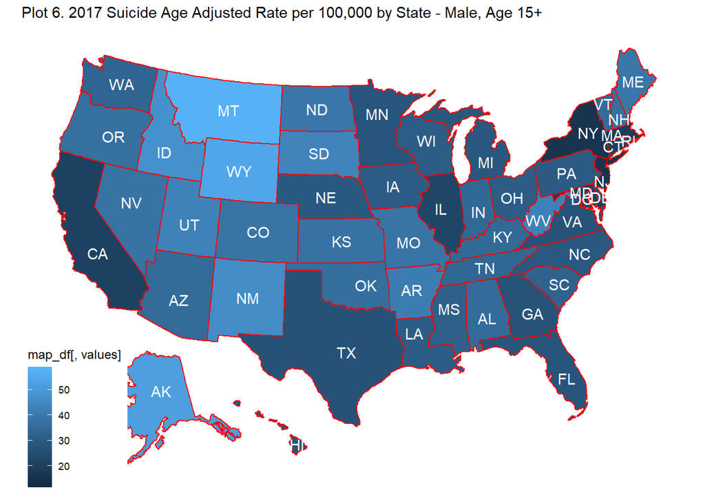

```r
plot_usmap(data = state2017M, values = "AARate", theme = theme_map(), labels = TRUE, label_color = "white", lines = "red")+
  labs(title = "Plot 6. 2017 Suicide Age Adjusted Rate per 100,000 by State - Male, Age 15+")
```

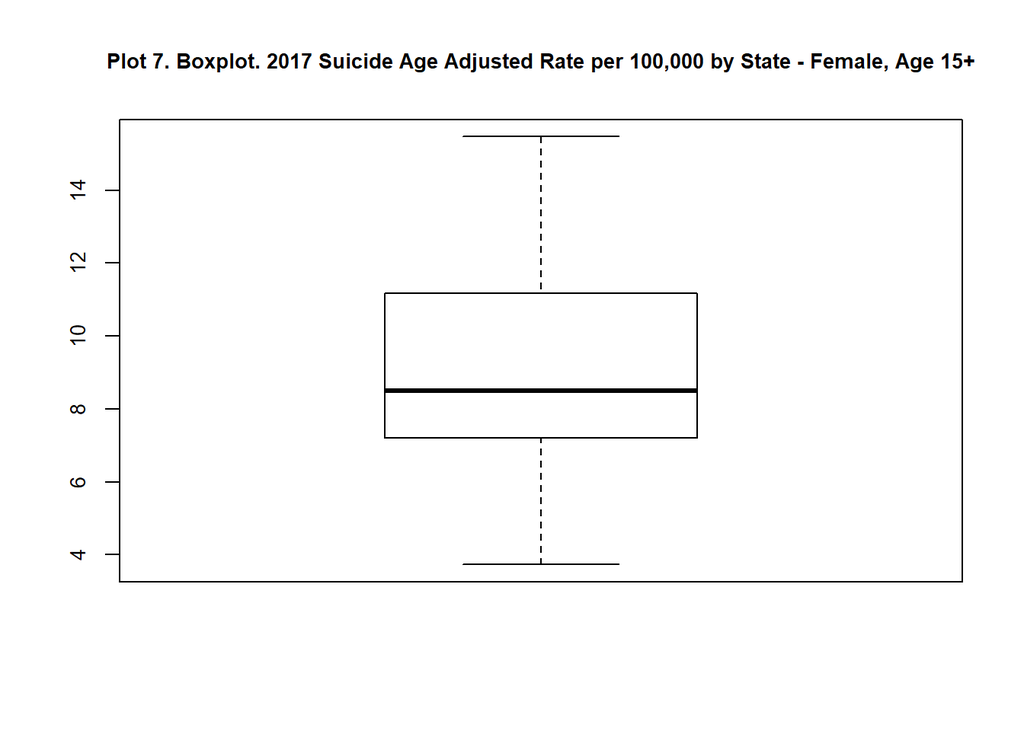

```r
state2017F<-filter(state2017GA, Gender=='Female')

state2017F$AARate1<-(state2017F$Age.Adjusted.Rate.Lower.95..Confidence.Interval+state2017F$Age.Adjusted.Rate.Upper.95..Confidence.Interval)/2

arrange(state2017F, AARate1)

par(ps = 10, cex = 1, cex.main = 1)

boxplot(state2017F$AARate1)

title(main="Plot 7. Boxplot. 2017 Suicide Age Adjusted Rate per 100,000 by State - Female, Age 15+")
```

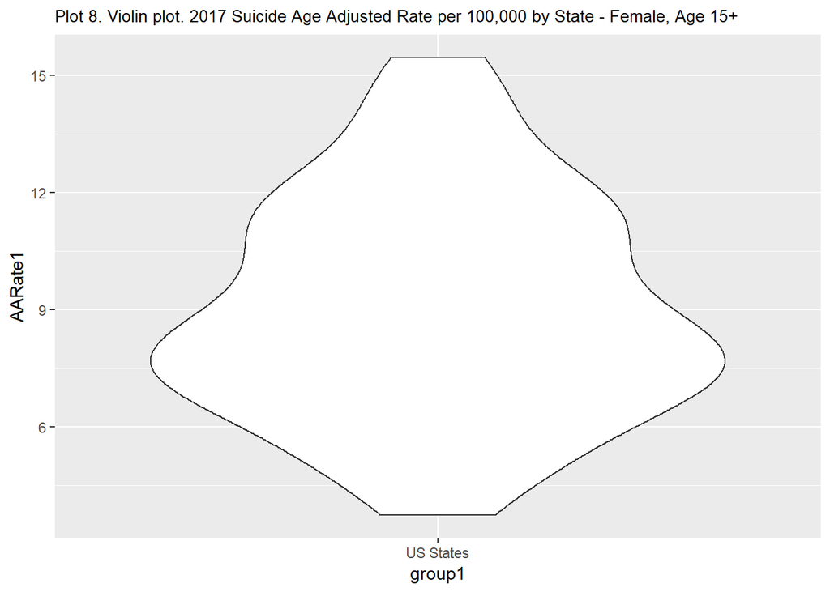

```r
ggplot(state2017F, aes(x=group1, y=AARate1))+geom_violin()+ggtitle("Plot 8. Violin plot. 2017 Suicide Age Adjusted Rate per 100,000 by State - Female, Age 15+")+theme(plot.title = element_text(size=10))
```

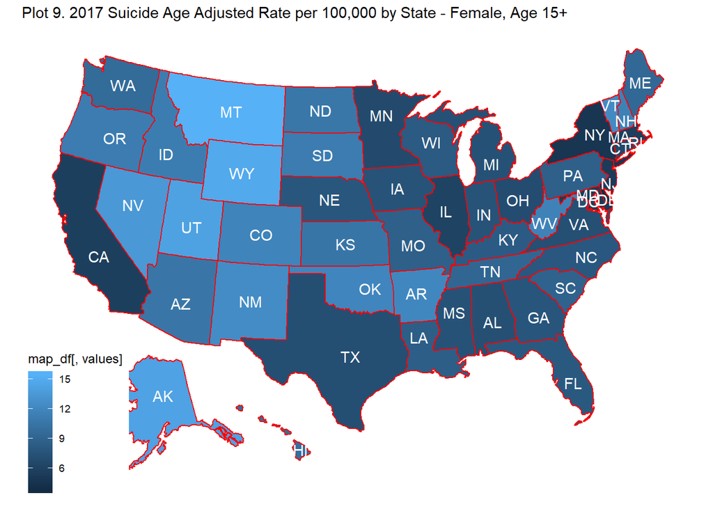

```r
plot_usmap(data = state2017F, values = "AARate1", theme = theme_map(), labels = TRUE, label_color = "white", lines = "red")+
  labs(title = "Plot 9. 2017 Suicide Age Adjusted Rate per 100,000 by State - Female, Age 15+")
```

For females, Delaware has the lowest rate, but data is unreliable. If we only use reliable data, then NY could be proud: tt has the lowest rate based on reliable data. Montana, on the other hand, has the highest rate.

### 5.1.3 2015-2017 Suicide Data by State, Gender, Ethnicity, Metro Status Age 15+ Only (To get closer to SAMHA’s age of 18+)

The third query used was 2015-2017 Suicide Data by state, gender, ethnicity, and metro residence. Data was limited to 3 years (2015-2017), cause of death (suicide), and age (15+). I have pulled 3 years of data to smooth it and to avoid unreliability label. I have still got some. We got a lot of detailed information from the data since it includes multiple aspects like gender, residency status, and ethnicity; therefore, it brings us one step closer to answering our question.

```r
state15_17<-read.table("C:/Final Project/Underlying Cause of Death, 2015-2017 Suicide State Ethnicity Gender Metro 15+.txt", header =TRUE, sep = "\t")

state15_17$state<-state15_17$State

state15_17$pop<-as.numeric(as.character(state15_17$Population))

state15_17$relFlag<-if (state15_17$Age.Adjusted.Rate=='Unreliable') {'U'} else {'R'}

state15_17$AARate<-(as.numeric(as.character(state15_17$Age.Adjusted.Rate.Lower.95..Confidence.Interval))+as.numeric(as.character(state15_17$Age.Adjusted.Rate.Upper.95..Confidence.Interval)))/2

arrange(state15_17, AARate)

state15_17$group1<-"US States"

state15_17C<-filter(state15_17, state=='Colorado')%>%select(state,Gender,X2013.Urbanization,AARate,Race,Hispanic.Origin,pop,relFlag)

state15_17M<-filter(state15_17, state=='Minnesota')%>%select(state,Gender,X2013.Urbanization,AARate,Race,Hispanic.Origin,pop,relFlag)

state15_17WM<-filter(state15_17, Race=='White'&Gender=='Male'&Hispanic.Origin=='Not Hispanic or Latino')

state15_17WM$prod<-state15_17WM$AARate*state15_17WM$pop

state15_17WM1<-select(state15_17WM,prod,pop,state)

state15_17WM1<-aggregate(.~state, data=state15_17WM1, FUN=sum)

state15_17WM1$AARate<-state15_17WM1$prod/state15_17WM1$pop

state15_17WF<-filter(state15_17, Race=='White'&Gender=='Female'&Hispanic.Origin=='Not Hispanic or Latino')

state15_17WF$prod<-state15_17WF$AARate*state15_17WF$pop

state15_17WF1<-select(state15_17WF,prod,pop,state)

state15_17WF1<-aggregate(.~state, data=state15_17WF1, FUN=sum)

state15_17WF1$AARate<-state15_17WF1$prod/state15_17WF1$pop

state15_17BM<-filter(state15_17, Race=='Black or African American'&Gender=='Male'&Hispanic.Origin=='Not Hispanic or Latino')

state15_17BM$prod<-state15_17BM$AARate*state15_17BM$pop

state15_17BM1<-select(state15_17BM,prod,pop,state)

state15_17BM1<-aggregate(.~state, data=state15_17BM1, FUN=sum)

state15_17BM1$AARate<-state15_17BM1$prod/state15_17BM1$pop

state15_17BF<-filter(state15_17, Race=='Black or African American'&Gender=='Female'&Hispanic.Origin=='Not Hispanic or Latino')

state15_17BF$prod<-state15_17BF$AARate*state15_17BF$pop

state15_17BF1<-select(state15_17BF,prod,pop,state)

state15_17BF1<-aggregate(.~state, data=state15_17BF1, FUN=sum)

state15_17BF1$AARate<-state15_17BF1$prod/state15_17BF1$pop

state15_17HM<-filter(state15_17, Gender=='Male'&Hispanic.Origin=='Hispanic or Latino')

state15_17HM$prod<-state15_17HM$AARate*state15_17HM$pop

state15_17HM1<-select(state15_17HM,prod,pop,state)

state15_17HM1<-aggregate(.~state, data=state15_17HM1, FUN=sum)

state15_17HM1$AARate<-state15_17HM1$prod/state15_17HM1$pop

state15_17HF<-filter(state15_17, Race=='Black or African American'&Gender=='Female'&Hispanic.Origin=='Not Hispanic or Latino')

state15_17HF$prod<-state15_17HF$AARate*state15_17HF$pop

state15_17HF1<-select(state15_17HF,prod,pop,state)

state15_17HF1<-aggregate(.~state, data=state15_17HF1, FUN=sum)

state15_17HF1$AARate<-state15_17HF1$prod/state15_17HF1$pop

state15_17%>%select(state,Race,Hispanic.Origin,Gender,X2013.Urbanization,Population, AARate)%>%filter(state=='Montana'|state=='District of Columbia')
```

### 5.1.4 2015-2017 Mortality Data by State, Gender, Ethnicity, Metro Status Age 15+ Only (To get closer to SAMHA’s age of 18+) - Drug Induced Indicator

```r
state15_17DI<-read.table("C:/Final Project/Underlying Cause of Death,  2015-2017 Drug Induced.txt", header =TRUE, sep = "\t")

state15_17DI$state<-state15_17DI$State

state15_17DI

state15_17DI$pop<-as.numeric(as.character(state15_17DI$Population))

state15_17DI$relFlag<-if (state15_17DI$Age.Adjusted.Rate=='Unreliable') {'U'} else {'R'}

state15_17DI$AARate<-(as.numeric(as.character(state15_17DI$Age.Adjusted.Rate.Lower.95..Confidence.Interval))+as.numeric(as.character(state15_17DI$Age.Adjusted.Rate.Upper.95..Confidence.Interval)))/2

arrange(state15_17DI, state)

state15_17DI$group1<-"US States"

state15_17WMDI<-filter(state15_17DI, Race=='White'&Gender=='Male'&Hispanic.Origin=='Not Hispanic or Latino')

state15_17WMDI$prod<-state15_17WMDI$AARate*state15_17WMDI$pop

state15_17WMDI1<-select(state15_17WMDI,prod,pop,state,Drug.Alcohol.Induced)

state15_17WMDI1<-aggregate(.~state+Drug.Alcohol.Induced, data=state15_17WMDI1, FUN=sum)

state15_17WMDI1$AARate1<-state15_17WMDI1$prod/state15_17WMDI1$pop

state15_17WMDI2<-select(state15_17WMDI1,state,Drug.Alcohol.Induced,AARate1)%>%spread(Drug.Alcohol.Induced,AARate1)

colnames(state15_17WMDI2)<-c('state','Alcohol','Other','Drug')

state15_17WMM<-merge(state15_17WM1,state15_17WMDI2,by='state')

state15_17WMC<-select(state15_17WMM,AARate, Alcohol, Other, Drug)

state15_17WMM

cor(state15_17WMC)

state15_17WFDI<-filter(state15_17DI, Race=='White'&Gender=='Female'&Hispanic.Origin=='Not Hispanic or Latino')

state15_17WFDI$prod<-state15_17WFDI$AARate*state15_17WFDI$pop

state15_17WFDI1<-select(state15_17WFDI,prod,pop,state,Drug.Alcohol.Induced)

state15_17WFDI1<-aggregate(.~state+Drug.Alcohol.Induced, data=state15_17WFDI1, FUN=sum)

state15_17WFDI1$AARate1<-state15_17WFDI1$prod/state15_17WFDI1$pop

state15_17WFDI2<-select(state15_17WFDI1,state,Drug.Alcohol.Induced,AARate1)%>%spread(Drug.Alcohol.Induced,AARate1)

colnames(state15_17WFDI2)<-c('state','Alcohol','Other','Drug')

state15_17WFM<-merge(state15_17WF1,state15_17WFDI2,by='state')

state15_17WFC<-select(state15_17WFM,AARate, Alcohol, Other, Drug)

state15_17WFM

cor(state15_17WFC)

state15_17BMDI<-filter(state15_17DI, Race=='Black or African American'&Gender=='Male'&Hispanic.Origin=='Not Hispanic or Latino')

state15_17BMDI
state15_17BMDI$prod<-state15_17BMDI$AARate*state15_17BMDI$pop

state15_17BMDI1<-select(state15_17BMDI,prod,pop,state,Drug.Alcohol.Induced)

state15_17BMDI1<-aggregate(.~state+Drug.Alcohol.Induced, data=state15_17BMDI1, FUN=sum)

state15_17BMDI1$AARate1<-state15_17BMDI1$prod/state15_17BMDI1$pop

state15_17BMDI2<-select(state15_17BMDI1,state,Drug.Alcohol.Induced,AARate1)%>%spread(Drug.Alcohol.Induced,AARate1)

colnames(state15_17BMDI2)<-c('state','Alcohol','Other','Drug')

state15_17BMDI2<-filter(state15_17BMDI2,!is.na(Alcohol)&!is.na(Drug))

state15_17BMM<-merge(state15_17BM1,state15_17BMDI2,by='state')

state15_17BMC<-select(state15_17BMM,AARate, Alcohol, Other, Drug)

state15_17BMM

cor(state15_17BMC)

state15_17BFDI<-filter(state15_17DI, Race=='Black or African American'&Gender=='Female'&Hispanic.Origin=='Not Hispanic or Latino')

state15_17BFDI$prod<-state15_17BFDI$AARate*state15_17BFDI$pop

state15_17BFDI1<-select(state15_17BFDI,prod,pop,state,Drug.Alcohol.Induced)

state15_17BFDI1<-aggregate(.~state+Drug.Alcohol.Induced, data=state15_17BFDI1, FUN=sum)

state15_17BFDI1$AARate1<-state15_17BFDI1$prod/state15_17BFDI1$pop

state15_17BFDI2<-select(state15_17BFDI1,state,Drug.Alcohol.Induced,AARate1)%>%spread(Drug.Alcohol.Induced,AARate1)

colnames(state15_17BFDI2)<-c('state','Alcohol','Other','Drug')

state15_17BMDI2<-filter(state15_17BMDI2,!is.na(Alcohol)&!is.na(Drug))

state15_17BFM<-merge(state15_17BF1,state15_17BFDI2,by='state')

state15_17BFC<-select(state15_17BFM,AARate, Alcohol, Other, Drug)

state15_17BFM

cor(state15_17BFC)

state15_17HMDI<-filter(state15_17DI, Gender=='Male'&Hispanic.Origin=='Hispanic or Latino')

state15_17HMDI

state15_17HMDI$prod<-state15_17HMDI$AARate*state15_17HMDI$pop

state15_17HMDI1<-select(state15_17HMDI,prod,pop,state,Drug.Alcohol.Induced)

state15_17HMDI1<-aggregate(.~state+Drug.Alcohol.Induced, data=state15_17HMDI1, FUN=sum)

state15_17HMDI1$AARate1<-state15_17HMDI1$prod/state15_17HMDI1$pop

state15_17HMDI2<-select(state15_17HMDI1,state,Drug.Alcohol.Induced,AARate1)%>%spread(Drug.Alcohol.Induced,AARate1)

colnames(state15_17HMDI2)<-c('state','Alcohol','Other','Drug')

state15_17HMDI2<-filter(state15_17HMDI2,!is.na(Alcohol)&!is.na(Drug))

state15_17HMM<-merge(state15_17HM1,state15_17HMDI2,by='state')

state15_17HMC<-select(state15_17HMM,AARate, Alcohol, Other, Drug)

state15_17HMM

cor(state15_17HMC)

state15_17HFDI<-filter(state15_17DI, Gender=='Female'&Hispanic.Origin=='Hispanic or Latino')

state15_17HFDI$prod<-state15_17HFDI$AARate*state15_17HFDI$pop

state15_17HFDI1<-select(state15_17HFDI,prod,pop,state,Drug.Alcohol.Induced)

state15_17HFDI1<-aggregate(.~state+Drug.Alcohol.Induced, data=state15_17HFDI1, FUN=sum)

state15_17HFDI1$AARate1<-state15_17HFDI1$prod/state15_17HFDI1$pop

state15_17HFDI2<-select(state15_17HFDI1,state,Drug.Alcohol.Induced,AARate1)%>%spread(Drug.Alcohol.Induced,AARate1)

colnames(state15_17HFDI2)<-c('state','Alcohol','Other','Drug')

state15_17HMDI2<-filter(state15_17HMDI2,!is.na(Alcohol)&!is.na(Drug))

state15_17HFM<-merge(state15_17HF1,state15_17HFDI2,by='state')

state15_17HFC<-select(state15_17HFM,AARate, Alcohol, Other, Drug)

state15_17HFM

cor(state15_17HFC)

state15_17DI%>%select(state,Race,Hispanic.Origin,Gender, Drug.Alcohol.Induced, AARate)%>%filter(state=='Montana'|state=='District of Columbia')
```

For White Non-Hispanic Male, Alcohol induced causes correlate with r=0.57.

For White Non-Hispanic Female Alcohol induced causes correlate with r=0.65.

For Black Non-Hispanic Male Alcohol induced causes correlate with r=0.43.

For Black Non-Hispanic Female Alcohol induced causes correlate with r=0.51.

For Hispanic Male Alcohol induced causes correlate with r=0.59.

For Hispanic Female Alcohol induced causes correlate with r=NA.

### 5.1.5 2008-2017 Suicide Data For Colorado and Minnesota, Gender, Ethnicity, Metro Status, and ICD10 groups Age 15+ Only (To get closer to SAMHA’s age of 18+)

The fourth query was 2008-2017 Suicide Data for Colorado and Minnesota by gender, ethnicity, metro residence, and ICD10 groups. Data was limited to 10 years (2008-2017) and age (15+). Please note that all disease was pulled since suicide was not the main aspect of the given data. I have pulled 10 years to get the most reliable data.

```r
state08_17<-read.table("C:/Final Project/Underlying Cause of Death, 2008-2017 Col Min by ICD.txt", header =TRUE, sep = "\t")

state08_17$state<-state08_17$State

state08_17$pop<-as.numeric(as.factor(state08_17$Population))

state08_17$relFlag<-if (state08_17$Age.Adjusted.Rate=='Unreliable') {'U'} else {'R'}

state08_17$AARate<-(as.numeric(as.character(state08_17$Age.Adjusted.Rate.Lower.95..Confidence.Interval))+as.numeric(as.character(state08_17$Age.Adjusted.Rate.Upper.95..Confidence.Interval)))/2

arrange(state08_17, AARate)

state08_17$group1<-"US States"

state08_17<-select(state08_17,state,Gender,X2013.Urbanization,AARate,Race,pop,relFlag,ICD.10.113.Cause.List)

state08_17M<-filter(state08_17,state=='Minnesota')

state08_17C<-filter(state08_17,state=='Colorado')
```

### 5.1.6 2008-2017 Mortality Data For All States, Gender, Ethnicity, and ICD10 groups Age 15+ Only

The fifth query was 2008-2017 Mortality Data for all sates by gender, ethnicity, and ICD10 groups. Data was limited to 10 years (2008-2017), ethnicity, and Metro areas. Please note that all disease was pulled since suicide was not only of mention. To get most reliable results data from 10 years ago was used.

```r
state08_17a<-read.table("C:/Final Project/Underlying Cause of Death, 2008-2017 Metro Non Hispanic 15+.txt", header =TRUE, sep = "\t")

#state08_17a<-filter(state08_17a,Crude.Rate!='Unreliable')



state08_17a$state<-state08_17a$State

state08_17a$pop<-as.numeric(as.factor(state08_17a$Population))
state08_17a$AARate<-(as.numeric(as.character(state08_17a$Age.Adjusted.Rate.Lower.95..Confidence.Interval))+as.numeric(as.character(state08_17a$Age.Adjusted.Rate.Upper.95..Confidence.Interval)))/2

state08_17a$group1<-"US States"

state08_17a<-select(state08_17a,state,Gender,AARate,Race,pop,ICD.10.113.Cause.List)

state08_17b<-spread(state08_17a,ICD.10.113.Cause.List,AARate)

state08_17b

state08_17bMB<-filter(state08_17b,Gender=='Male',Race=='Black or African American')

state08_17bMB

state08_17bMBC<-state08_17bMB[-c(1:5)]

state08_17bMBC<-state08_17bMBC[, -which(colMeans(is.na(state08_17bMBC)) > 0.25)]

state08_17bMBC

colnames(state08_17bMBC)[13] <- "Suicide"

state08_17bMBC<-filter(state08_17bMBC,!is.na(Suicide))

cor(as.matrix(state08_17bMBC[,13]), as.matrix(state08_17bMBC[,-13]), use = "pairwise.complete.obs")

state08_17bMW<-filter(state08_17b,Gender=='Male',Race=='White')

state08_17bMW

state08_17bMWC<-state08_17bMW[-c(1:5)]

state08_17bMWC<-state08_17bMWC[, -which(colMeans(is.na(state08_17bMWC)) > 0.1)]

state08_17bMWC

colnames(state08_17bMWC)[19] <- "Suicide"

state08_17bMBC<-filter(state08_17bMWC,!is.na(Suicide))

cor(as.matrix(state08_17bMWC[,19]), as.matrix(state08_17bMWC[,-11]), use = "pairwise.complete.obs")
```

### 5.1.7 2017 Suicide Data For DC and Montana by State, Ethnicity

The 6th query was 2017 Suicide Data for DC and Montana by ethnicity and ICD10 groups. Data was limited to 2017 and DC and Montana only.

```r
state17_DC_Mo<-read.table("C:/Final Project/Underlying Cause of Death, 2017 Monata vs DC.txt", header =TRUE, sep = "\t")
```

## 5.2 SAMHA State Prevalance of Drug and Alcohol Use and Mental Issues.

This data does not provide suicide rates; however, it does provide statistics on alcohol, drug, and mental health by state. It should help us understand which states have issues with substance abuse and mental health. The data is provided in Excel format. I have loaded the file on my GitHub account(M.Groysman 2018). The file has multiple tabs. We do not need all of them, so we will only load the ones we need:

1. Drug use, any drug
2. Drug use, not marijuana
3. Drug use, heroin
4. Alcohol use
5. Alcohol use, binge
6. Drug Abuse disorder
7. Pain Reliever Abuse disorder
8. Alcohol Abuse disorder
9. Substance Abuse disorder
10. Serious Mental Disorder
11. Any Mental Disorder
12. Serious Thoughts of Suicide, the most important table for us. Please note that this is not a suicide rate. However, we will work with model that:

Suicide thought->Suicide Planning->Suicide Attempt->Suicide(in case of successful attempt)

### 5.2.1 Data Load

```r
drug_use <- read_excel("C:/Final Project/NSDUHsaeExcelTabs2017.xlsx", sheet = "Table 1")

drug_use <- drug_use[6:62, ]

colnames(drug_use) <- c("Index", "state", "Y12P", "Y12P_LE", "Y12P_HE", "Y12_17",
    "Y12_17_LE", "Y12_17_HE", "Y18_25", "Y18_25_LE", "Y18_25_HE", "Y26P", "Y26P_LE",
    "Y26P_HE", "Y18P", "Y18P_LE", "Y18P_HE")

drug_uset <- transform(drug_use, Y12P = as.numeric(Y12P), Y18P = as.numeric(Y18P),
    Y18_25 = as.numeric(Y18_25), Y26P = as.numeric(Y26P))

drug_uset %>% arrange(desc(Y12P))
```

```r
drug_use1 <- read_excel("C:/Final Project/NSDUHsaeExcelTabs2017.xlsx", sheet = "Table 6")

drug_use1<-drug_use1[6:62,]

colnames(drug_use1)<-c("Index","state","Y12P","Y12P_LE","Y12P_HE","Y12_17","Y12_17_LE","Y12_17_HE","Y18_25","Y18_25_LE","Y18_25_HE","Y26P","Y26P_LE","Y26P_HE","Y18P","Y18P_LE","Y18P_HE")

drug_uset1<-transform(drug_use1,Y12P = as.numeric(Y12P),Y18P = as.numeric(Y18P),Y18_25 = as.numeric(Y18_25), Y26P = as.numeric(Y26P))

drug_uset1%>%arrange(desc(Y12P))
```

```r
drug_useh <- read_excel("C:/Final Project/NSDUHsaeExcelTabs2017.xlsx", sheet = "Table 9")

drug_useh<-drug_useh[6:62,]

colnames(drug_useh)<-c("Index","state","Y12P","Y12P_LE","Y12P_HE","Y12_17","Y12_17_LE","Y12_17_HE","Y18_25","Y18_25_LE","Y18_25_HE","Y26P","Y26P_LE","Y26P_HE","Y18P","Y18P_LE","Y18P_HE")

drug_useth<-transform(drug_useh, Y12P = as.numeric(Y12P),Y18P = as.numeric(Y18P),Y18_25 = as.numeric(Y18_25), Y26P = as.numeric(Y26P))

drug_useth%>%arrange(desc(Y12P))
```

```r
alc_use <- read_excel("C:/Final Project/NSDUHsaeExcelTabs2017.xlsx", sheet = "Table 13")

alc_use<-alc_use[6:62,]

colnames(alc_use)<-c("Index","state","Y12P","Y12P_LE","Y12P_HE","Y12_17","Y12_17_LE","Y12_17_HE","Y18_25","Y18_25_LE","Y18_25_HE","Y26P","Y26P_LE","Y26P_HE","Y18P","Y18P_LE","Y18P_HE")

alc_uset<-transform(alc_use,  Y12P = as.numeric(Y12P),Y18P = as.numeric(Y18P),Y18_25 = as.numeric(Y18_25), Y26P = as.numeric(Y26P))

alc_uset%>%arrange(desc(Y12P))
```

```r
alc_useb <- read_excel("C:/Final Project/NSDUHsaeExcelTabs2017.xlsx", sheet = "Table 14")

alc_useb<-alc_useb[6:62,]

colnames(alc_useb)<-c("Index","state","Y12P","Y12P_LE","Y12P_HE","Y12_17","Y12_17_LE","Y12_17_HE","Y18_25","Y18_25_LE","Y18_25_HE","Y26P","Y26P_LE","Y26P_HE","Y18P","Y18P_LE","Y18P_HE")

alc_usebt<-transform(alc_useb, Y12P = as.numeric(Y12P),Y18P = as.numeric(Y18P),Y18_25 = as.numeric(Y18_25), Y26P = as.numeric(Y26P))

alc_usebt%>%arrange(desc(Y12P))
```

```r
drug_d <- read_excel("C:/Final Project/NSDUHsaeExcelTabs2017.xlsx", sheet = "Table 20")

drug_d<-drug_d[6:62,]

colnames(drug_d)<-c("Index","state","Y12P","Y12P_LE","Y12P_HE","Y12_17","Y12_17_LE","Y12_17_HE","Y18_25","Y18_25_LE","Y18_25_HE","Y26P","Y26P_LE","Y26P_HE","Y18P","Y18P_LE","Y18P_HE")

drug_dt<-transform(drug_d, Y12P = as.numeric(Y12P),Y18P = as.numeric(Y18P),Y18_25 = as.numeric(Y18_25), Y26P = as.numeric(Y26P))

drug_dt%>%arrange(desc(Y12P))
```

```r
pain_d <- read_excel("C:/Final Project/NSDUHsaeExcelTabs2017.xlsx", sheet = "Table 21")

pain_d<-pain_d[6:62,]

colnames(pain_d)<-c("Index","state","Y12P","Y12P_LE","Y12P_HE","Y12_17","Y12_17_LE","Y12_17_HE","Y18_25","Y18_25_LE","Y18_25_HE","Y26P","Y26P_LE","Y26P_HE","Y18P","Y18P_LE","Y18P_HE")

pain_dt<-transform(pain_d, Y12P = as.numeric(Y12P),Y18P = as.numeric(Y18P),Y18_25 = as.numeric(Y18_25), Y26P = as.numeric(Y26P))

pain_dt%>%arrange(desc(Y12P))
```

```r
alc_d <- read_excel("C:/Final Project/NSDUHsaeExcelTabs2017.xlsx", sheet = "Table 22")

alc_d<-alc_d[6:62,]

colnames(alc_d)<-c("Index","state","Y12P","Y12P_LE","Y12P_HE","Y12_17","Y12_17_LE","Y12_17_HE","Y18_25","Y18_25_LE","Y18_25_HE","Y26P","Y26P_LE","Y26P_HE","Y18P","Y18P_LE","Y18P_HE")

alc_dt<-transform(alc_d, Y12P = as.numeric(Y12P),Y18P = as.numeric(Y18P),Y18_25 = as.numeric(Y18_25))

alc_dt%>%arrange(desc(Y12P))
```

```r
sa_d <- read_excel("C:/Final Project/NSDUHsaeExcelTabs2017.xlsx", sheet = "Table 23")

sa_d<-sa_d[6:62,]

colnames(sa_d)<-c("Index","state","Y12P","Y12P_LE","Y12P_HE","Y12_17","Y12_17_LE","Y12_17_HE","Y18_25","Y18_25_LE","Y18_25_HE","Y26P","Y26P_LE","Y26P_HE","Y18P","Y18P_LE","Y18P_HE")

sa_dt<-transform(sa_d, Y12P = as.numeric(Y12P),Y18P = as.numeric(Y18P),Y18_25 = as.numeric(Y18_25))

sa_dt%>%arrange(desc(Y12P))
```

```r
mh_d <- read_excel("C:/Final Project/NSDUHsaeExcelTabs2017.xlsx", sheet = "Table 27")

mh_d<-mh_d[6:62,]

colnames(mh_d)<-c("Index","state","Y18P","Y18P_LE","Y18P_HE","Y18_25","Y18_25_LE","Y18_25_HE","Y26P","Y26P_LE","Y26P_HE")

mh_dt<-transform(mh_d, Y18P = as.numeric(Y18P))

mh_dt%>%arrange(desc(Y18P))
```

```r
amh_d <- read_excel("C:/Final Project/NSDUHsaeExcelTabs2017.xlsx", sheet = "Table 28")

amh_d<-amh_d[6:62,]

colnames(amh_d)<-c("Index","state","Y18P","Y18P_LE","Y18P_HE","Y18_25","Y18_25_LE","Y18_25_HE","Y26P","Y26P_LE","Y26P_HE")

amh_dt<-transform(amh_d, Y18P = as.numeric(Y18P))

amh_dt%>%arrange(desc(Y18P))
```

### 5.2.2 Serious thoughts of suicide, rate among 18+ cohort

```r
suicide_t <- read_excel("C:/Final Project/NSDUHsaeExcelTabs2017.xlsx", sheet = "Table 30")

suicide_t<-suicide_t[6:62,]

colnames(suicide_t)<-c("Index","state","Y18P","Y18P_LE","Y18P_HE","Y18_25","Y18_25_LE","Y18_25_HE","Y26P","Y26P_LE","Y26P_HE")

suicide_t%>%filter(!is.na(Index))%>%filter(!state %in% c('Total U.S.','Midwest','West','South','Northeast'))

suicide_tt<-transform(suicide_t, Y18P = as.numeric(Y18P),Y18_25 = as.numeric(Y18_25),Y26P = as.numeric(Y26P))

suicide_tt1<-filter(suicide_tt,!is.na(Y18P)&substr(suicide_tt$state,1,3)!='Tot')%>%arrange(desc(Y18P))

arrange(suicide_tt1,desc(Y18P))

suicide_tt1$group1<-"US States"
```

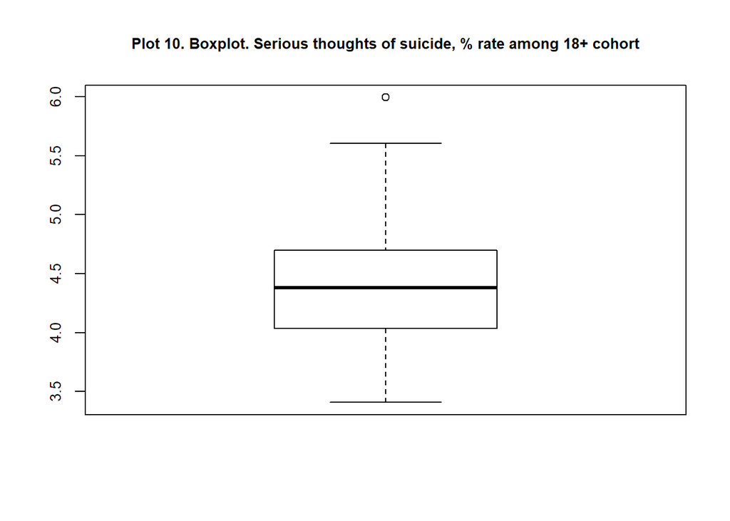

```r
par(ps = 10, cex = 1, cex.main = 1)

boxplot(suicide_tt1$Y18P*100)

title(main="Plot 10. Boxplot. Serious thoughts of suicide, % rate among 18+ cohort")
```

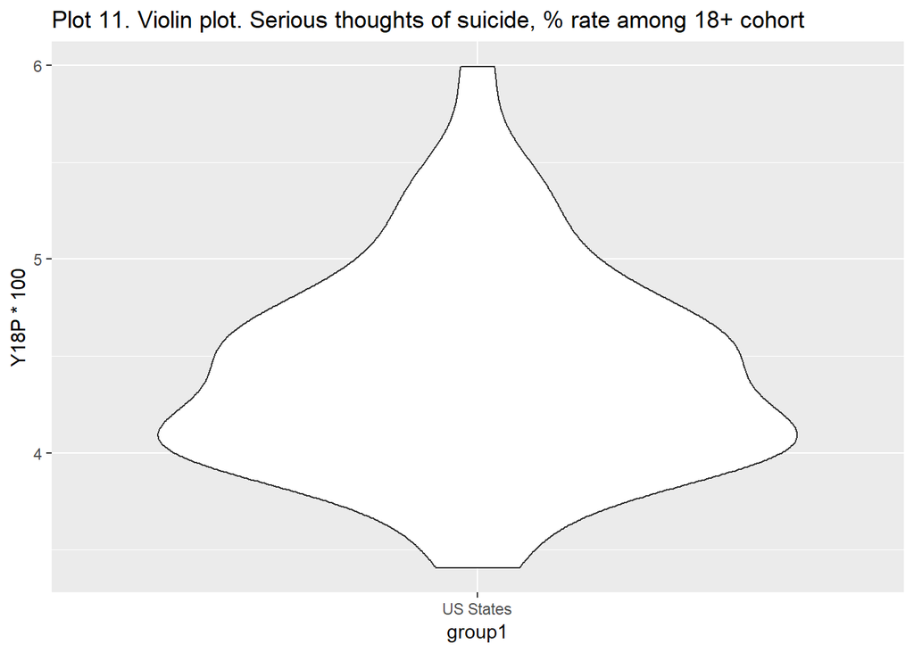

```r
ggplot(suicide_tt1, aes(x=group1, y=Y18P*100))+geom_violin()+ggtitle("Plot 11. Violin plot. Serious thoughts of suicide, % rate among 18+ cohort")+theme(plot.title = element_text(size=13))
```

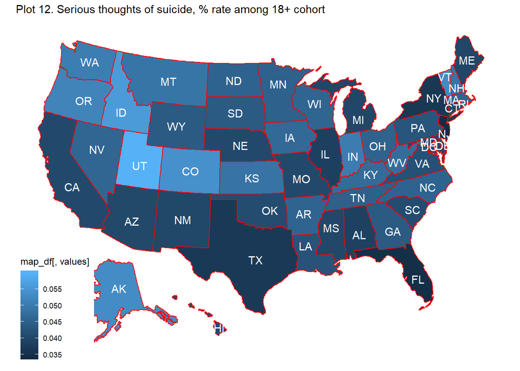

```r
plot_usmap(data = suicide_tt1, values = "Y18P", theme = theme_map(), labels = TRUE, label_color = "white", lines = "red")+
  labs(title = "Plot 12. Serious thoughts of suicide, % rate among 18+ cohort")
```

#### 5.2.2.1 Discussion of the table:

Utah has the highest % of population with thoughts of suicide, NJ had the lowest. Utah seems to be an outline. Interestingly, Utah has high but not highest rate of suicide among US states. Alaska and Montana have higher rates.

#### 5.2.2.2 Serious thoughts of suicide, rate among younger cohort, 18-25

Among young people, Alaska is slightly ahead of Utah in suicide thoughts. Apparently, Utah has teen suicide crisis(Riess 2016).

```r
suicide_tt1%>%arrange(desc(Y18_25))
```

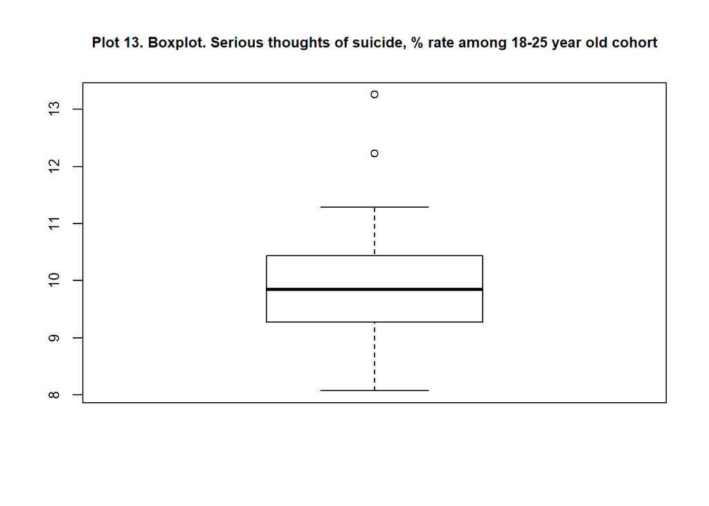

```r
par(ps = 10, cex = 1, cex.main = 1)

boxplot(suicide_tt1$Y18_25*100)

title(main="Plot 13. Boxplot. Serious thoughts of suicide, % rate among 18-25 year old cohort")
```

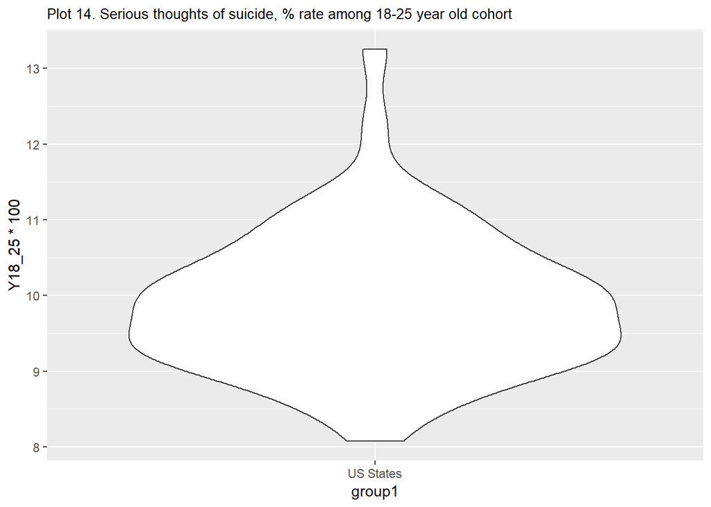

```r
ggplot(suicide_tt1, aes(x=group1, y=Y18_25*100)) +geom_violin()+ggtitle("Plot 14. Serious thoughts of suicide, % rate among 18-25 year old cohort")+theme(plot.title = element_text(size=10))
```

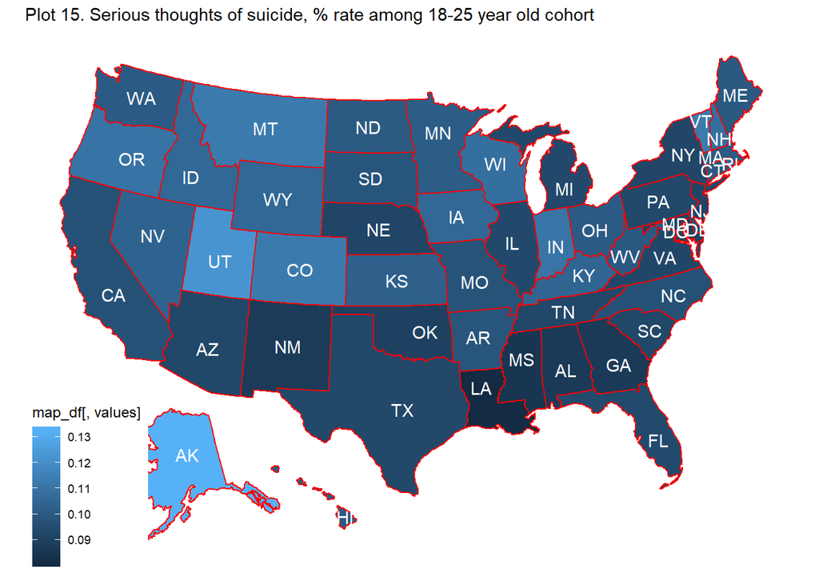

```r
plot_usmap(data = suicide_tt1, values = "Y18_25", theme = theme_map(), labels = TRUE, label_color = "white", lines = "red")+
  labs(title = "Plot 15. Serious thoughts of suicide, % rate among 18-25 year old cohort")
```

### 5.2.3 Serious thoughts of suicide, rate among older cohort, 26+

Both Alaska and Utah seem to be outliers. Among older people (26+), Idaho, state adjutant to Utah, has the highest number with suicide thoughts, while NJ again has the lowest number.

```r
suicide_tt1%>%arrange(desc(Y26P))
```

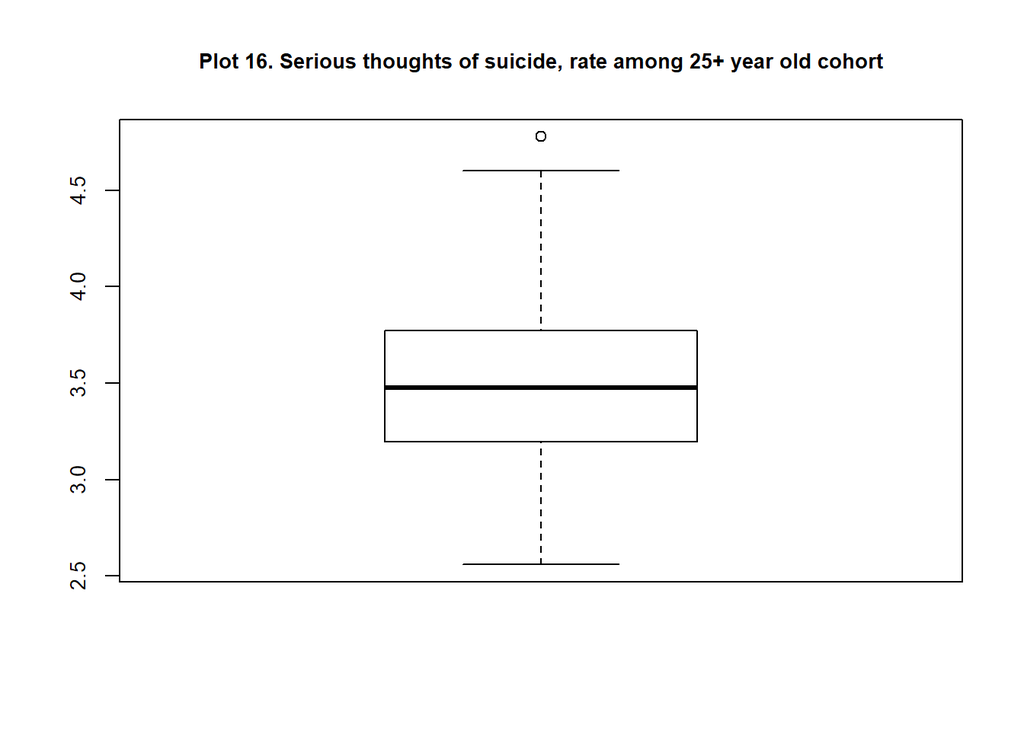

```r
par(ps = 10, cex = 1, cex.main = 1)

boxplot(suicide_tt1$Y26P*100)

title(main="Plot 16. Serious thoughts of suicide, rate among 25+ year old cohort")
```

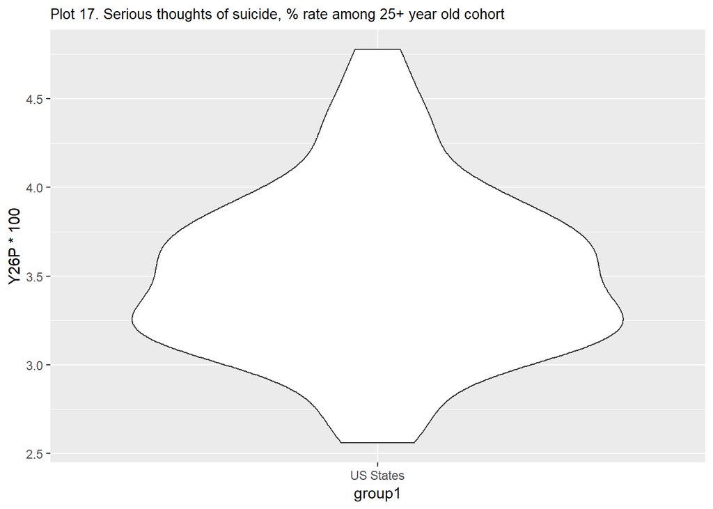

```r
ggplot(suicide_tt1, aes(x=group1, y=Y26P*100))+geom_violin()+ggtitle("Plot 17. Serious thoughts of suicide, % rate among 25+ year old cohort")+theme(plot.title = element_text(size=10))
```

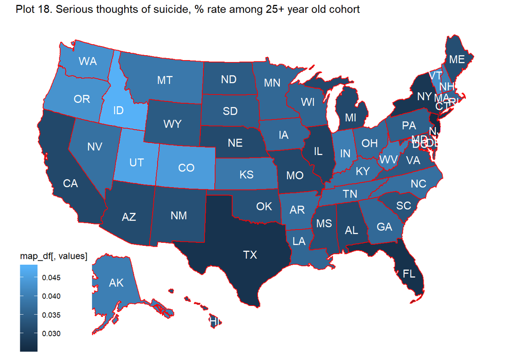

```r
plot_usmap(data = suicide_tt1, values = "Y26P", theme = theme_map(), labels = TRUE, label_color = "white", lines = "red")+
  labs(title = "Plot 18. Serious thoughts of suicide, % rate among 25+ year old cohort")
```

### 5.2.4 SAMHA Master Table

Let’s put a SAMHA master table to include all separate pieces together

1. Drug use, any drug
2. Drug use, not marijuana
3. Drug use, heroin
4. Alcohol use
5. Alcohol use, binge
6. Drug Abuse disorder
7. Pain Reliever Abuse disorder
8. Alcohol Abuse disorder
9. Substance Abuse disorder
10. Serious Mental Disorder
11. Any Mental Disorder
12. Serious Thoughts of Suicide

```r
drug_usetA<-select(drug_uset,"state","Y18P")

colnames(drug_usetA)<-c("state","DrugAny")

drug_uset1A<-select(drug_uset1,"state","Y18P")

colnames(drug_uset1A)<-c("state","DrugNoM")

drug_useth1<-select(drug_useth,"state","Y18P")

colnames(drug_useth1)<-c("state","Heroin")

alc_uset1<-select(alc_uset,"state","Y18P")

colnames(alc_uset1)<-c("state","AlcUse")

alc_usebt1<-select(alc_usebt,"state","Y18P")

colnames(alc_usebt1)<-c("state","Binge")

drug_dt1<-select(drug_dt,"state","Y18P")

colnames(drug_dt1)<-c("state","DrugDis")

pain_dt1<-select(pain_dt,"state","Y18P")

colnames(pain_dt1)<-c("state","Painkillers")

alc_dt1<-select(alc_dt,"state","Y18P")

colnames(alc_dt1)<-c("state","AlcDis")

sa_dt1<-select(sa_dt,"state","Y18P")

colnames(sa_dt1)<-c("state","SubAbuse")

suicide_tt2<-select(suicide_tt1,"state","Y18P")

colnames(suicide_tt2)<-c("state","ThoughtSuic")

mh_dt1<-select(mh_dt,"state","Y18P")

colnames(mh_dt1)<-c("state","SerMH")


SAMHA_master<-Reduce(function(x,y) merge(x = x, y = y, by = "state"), list(suicide_tt2, mh_dt1, pain_dt1, drug_uset1A, drug_usetA, alc_usebt1,drug_dt1, alc_dt1, alc_uset1, drug_useth1, sa_dt1))

SAMHA_master<-SAMHA_master%>%filter(!state %in% c('Total U.S.','Midwest','West','South','Northeast'))
```

## 5.3 2016 Suicide Rate by Country

```r
wikiURL<-"https://en.wikipedia.org/wiki/List_of_countries_by_suicide_rate"

wikiData <- getURL(wikiURL)

countries <- readHTMLTable(wikiData)

countries1<-countries[[3]]

countries2<-countries1[-1,]

colnames(countries2)<-c("Rank","Country", "AgeAdjRateT","a","b","c","d","e")

countries2$temp<-as.character(countries2$AgeAdjRateT)

countries2$AgeAdjRate<-as.numeric(countries2$temp)

countries2<-countries2%>%select("Rank","Country","AgeAdjRate")

countries2$Country<-gsub("\\(more info\\)", "", as.character(countries2$Country))

head(countries2)%>%
  kable() %>%
  kable_styling()
```

|  | Rank | Country | AgeAdjRate |
| --- | --- | --- | --- |
| 2 | 1 | Guyana | 30.2 |
| 3 | 2 | Lesotho | 28.9 |
| 4 | 3 | Russia | 26.5 |
| 5 | 4 | Lithuania | 25.7 |
| 6 | 5 | Suriname | 23.2 |
| 7 | 6 | Cote d’Ivoire | 23.0 |

# 6 Analysis

Correlation classification(Gerstman Unknown):

0 < |r| < .3 weak correlation .3 < |r| < .7 moderate correlation |r| > 0.7 strong correlation

## 6.1 CDC Wonder Data.

### 6.1.1 2017 State Suicide Rate.

Let’s check for normality. The distribution of our data does somewhat resemble to normal. Montana creates a long tail.

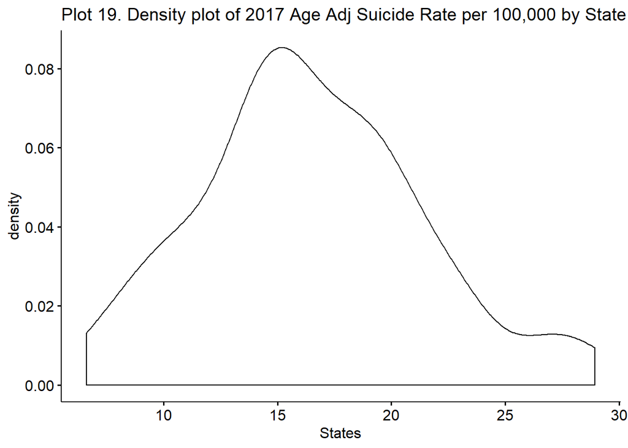

```r
ggdensity(state2017$AARate,
          main = "Plot 19. Density plot of 2017 Age Adj Suicide Rate per 100,000 by State",
          xlab = "States")
```

#### 6.1.1.1 US States vs World Countries: Suicide Rate

Next let’s merge US State data into Wiki Country data to see how US States would rank if they were independent countries.

```r
stateWiki<-select(state2017,State,AARate)

colnames(stateWiki)<-c("Country","AgeAdjRate")

stateWiki$USflag<-"Y"

countries3<-select(countries2,Country, AgeAdjRate)

countries3$USflag<-"N"

countryState <- rbind(countries3, stateWiki)

countryState<-arrange(countryState,desc(AgeAdjRate))

countryState$rank <- NA

countryState$rank<- 1:nrow(countryState)

countryState<-select(countryState,rank, Country, USflag, AgeAdjRate)

countryState %>%
  kable() %>%
  kable_styling()
```

| rank | Country | USflag | AgeAdjRate |
| --- | --- | --- | --- |
| 1 | Guyana | N | 30.200 |
| 2 | Montana | Y | 28.943 |
| 3 | Lesotho | N | 28.900 |
| 4 | Alaska | Y | 27.014 |
| 5 | Wyoming | Y | 26.940 |
| 6 | Russia | N | 26.500 |
| 7 | Lithuania | N | 25.700 |
| 8 | New Mexico | Y | 23.300 |
| 9 | Suriname | N | 23.200 |
| 10 | Idaho | Y | 23.168 |
| 11 | Cote d’Ivoire | N | 23.000 |
| 12 | Kazakhstan | N | 22.800 |
| 13 | Utah | Y | 22.691 |
| 14 | South Dakota | Y | 22.517 |
| 15 | Equatorial Guinea | N | 22.000 |
| 16 | Belarus | N | 21.400 |
| 17 | West Virginia | Y | 21.064 |
| 18 | Arkansas | Y | 20.800 |
| 19 | Colorado | Y | 20.339 |
| 20 | Nevada | Y | 20.285 |
| 21 | South Korea | N | 20.200 |
| 22 | North Dakota | Y | 20.083 |
| 23 | Ugandab | N | 20.000 |
| 24 | Cameroon | N | 19.500 |
| 25 | Kansas | Y | 19.131 |
| 26 | Oklahoma | Y | 19.129 |
| 27 | Zimbabwe | N | 19.100 |
| 28 | Oregon | Y | 18.998 |
| 29 | New Hampshire | Y | 18.898 |
| 30 | Maine | Y | 18.874 |

[output cut: 203 more lines]

It is shocking, but 5 US states made in top 10. Montana has the 2nd highers suicide rate. 3 states are ahead of Russia, and Russia has very high suicide rate.

Let’s create a violin plot of the distribution.

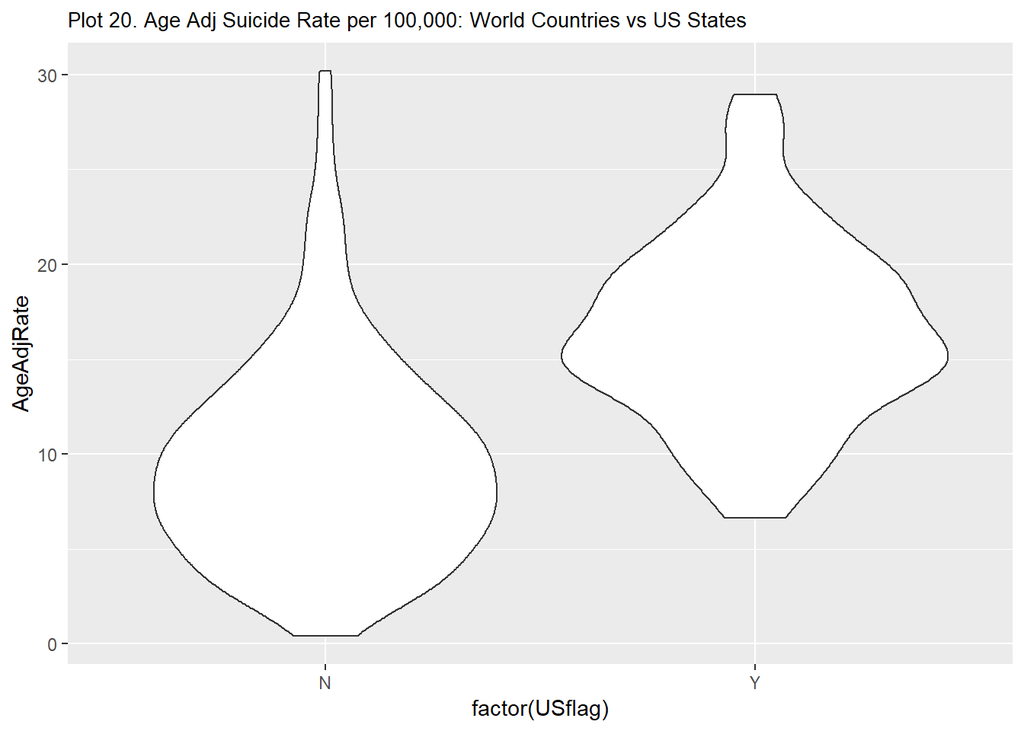

```r
p <- ggplot(countryState, aes(factor(USflag), AgeAdjRate))

p + geom_violin()+ggtitle("Plot 20. Age Adj Suicide Rate per 100,000: World Countries vs US States")+theme(plot.title = element_text(size=10))
```

The plot provides devasting results. US is doing very poorly. Please note that in last 2 decades while US suicide rate was steadily rising, the rest of the world was moving in opposite direction. Rates of suicide across of Asia and Europe have been dropping.

#### 6.1.1.2 Suicide Rates vs Serious Thoughts of Suicide by State

Let’s merge CDC and SAMHA data to see if there is correlation between suicide rates and serious thoughts of suicide. It should help us to validate our assumption, stated earlier that:

Suicide thought->Suicide Planning->Suicide Attempt->Suicide(in case of successful attempt)

```r
suic_r_t<-merge(state2017, suicide_tt1, by = "state")

cor(suic_r_t$Y18P, suic_r_t$AARate)
```

```
## [1] 0.5509664
```

```r
#suic_r_t
```

Correlation is moderate. R is only 0.55. Not as high as I expected.

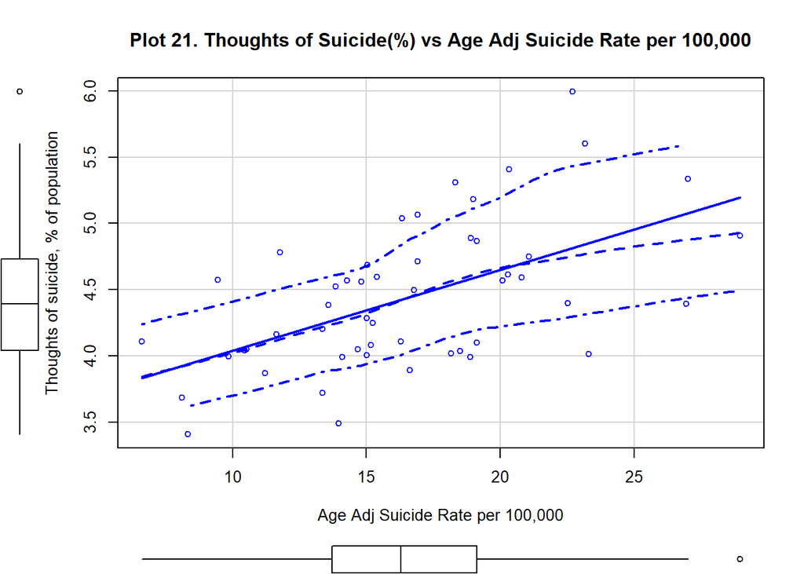

```r
scatterplot(suic_r_t$Y18P*100~suic_r_t$AARate, ylab="Thoughts of suicide, % of population", xlab="Age Adj Suicide Rate per 100,000",
            main="Plot 21. Thoughts of Suicide(%) vs Age Adj Suicide Rate per 100,000")
```

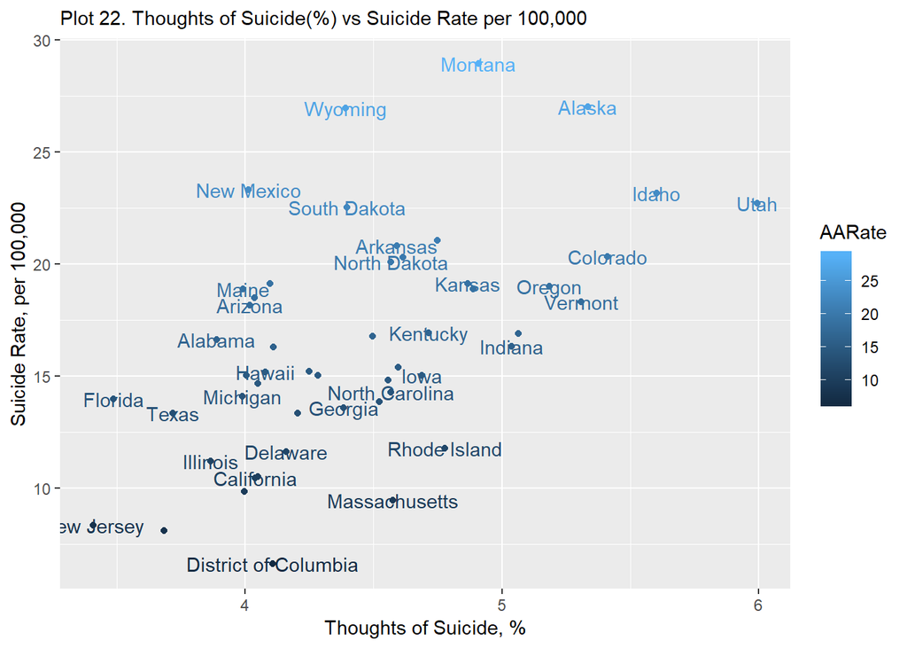

```r
ggplot(suic_r_t, aes(Y18P*100,AARate, color = AARate)) + geom_point() + geom_text(aes(label=state), check_overlap = TRUE)+
  labs(subtitle="Plot 22. Thoughts of Suicide(%) vs Suicide Rate per 100,000", x="Thoughts of Suicide, %", y="Suicide Rate, per 100,000")
```

Interesting question is why so many people seriously think about suicide while relativly few commit suicide, while in Montana not that many people seriously think about suicide while so many actually commit it? Is it the way data is collected or is it something else. Later we will see that gun ownership could play a role.

#### 6.1.1.3 Suicide Rates vs SAMHA Survey.

Let’s check correlation between suicide rate and other SAMHA’s variables:

Vs Drug Use, Any - no correlation, r=0.00. Very Interesting. It seems variables are perfectly independent.

Vs Heroin Use - practically no correlation, r=-0.04

Vs Alcohol Use and Binge Drinking - week negative correlation(!), r=-0.22 and r=-0.2. Basically what we are seeing that higher alcohol consumption weakly predicts lower suicide rate. Not what I have expected.

Vs Painkillers Abuse - finally we got some decent correlation. r=0.42.

Vs Serious Mental Illness - BINGO! r=0.57. Hard to believe but serious mental illness is a slightly better predictor than serious thoughts of suicide.

```r
state2017C<-select(state2017,state, AARate)

suic_cor<-merge(state2017C, SAMHA_master, by = "state")

suic_cor1<-suic_cor

suic_cor1$state<-NULL

res <- cor(suic_cor1)

round(res, 2)%>%
  kable() %>%
  kable_styling()
```

|  | AARate | ThoughtSuic | SerMH | Painkillers | DrugNoM | DrugAny | Binge | DrugDis | AlcDis | AlcUse | Heroin | SubAbuse |
| --- | --- | --- | --- | --- | --- | --- | --- | --- | --- | --- | --- | --- |
| AARate | 1.00 | 0.55 | 0.57 | 0.42 | -0.16 | 0.00 | -0.20 | 0.05 | 0.10 | -0.22 | -0.04 | 0.04 |
| ThoughtSuic | 0.55 | 1.00 | 0.80 | 0.46 | 0.24 | 0.31 | -0.07 | 0.31 | 0.26 | -0.02 | 0.16 | 0.29 |
| SerMH | 0.57 | 0.80 | 1.00 | 0.78 | 0.18 | 0.18 | -0.21 | 0.26 | 0.13 | -0.25 | 0.24 | 0.18 |
| Painkillers | 0.42 | 0.46 | 0.78 | 1.00 | -0.01 | -0.05 | -0.29 | 0.13 | -0.13 | -0.35 | 0.24 | -0.03 |
| DrugNoM | -0.16 | 0.24 | 0.18 | -0.01 | 1.00 | 0.83 | 0.36 | 0.80 | 0.57 | 0.38 | 0.14 | 0.68 |
| DrugAny | 0.00 | 0.31 | 0.18 | -0.05 | 0.83 | 1.00 | 0.32 | 0.81 | 0.57 | 0.48 | 0.22 | 0.70 |
| Binge | -0.20 | -0.07 | -0.21 | -0.29 | 0.36 | 0.32 | 1.00 | 0.23 | 0.77 | 0.88 | 0.00 | 0.70 |
| DrugDis | 0.05 | 0.31 | 0.26 | 0.13 | 0.80 | 0.81 | 0.23 | 1.00 | 0.52 | 0.27 | 0.35 | 0.69 |
| AlcDis | 0.10 | 0.26 | 0.13 | -0.13 | 0.57 | 0.57 | 0.77 | 0.52 | 1.00 | 0.70 | 0.01 | 0.95 |
| AlcUse | -0.22 | -0.02 | -0.25 | -0.35 | 0.38 | 0.48 | 0.88 | 0.27 | 0.70 | 1.00 | 0.13 | 0.67 |
| Heroin | -0.04 | 0.16 | 0.24 | 0.24 | 0.14 | 0.22 | 0.00 | 0.35 | 0.01 | 0.13 | 1.00 | 0.13 |
| SubAbuse | 0.04 | 0.29 | 0.18 | -0.03 | 0.68 | 0.70 | 0.70 | 0.69 | 0.95 | 0.67 | 0.13 | 1.00 |

#### 6.1.1.4 Suicide Rates vs Serious Mental Illness Rates by State.

Let’s create scatterplots of the 2 variables. We see the same outliers again: Montana, Alaska, and New Mexico, all have high suicide rates, but their rates of mental illness are not all that high.

[figure not shown]

```r
scatterplot(suic_cor$SerMH*100~suic_cor$AARate, xlab="Serious Mental Illness(%)", ylab="Age Adj Suicide Rate per 100,000",
            main="Plot 22A. Serious Mental Illness(%) vs Age Adj Suicide Rate, per 100,000")
```

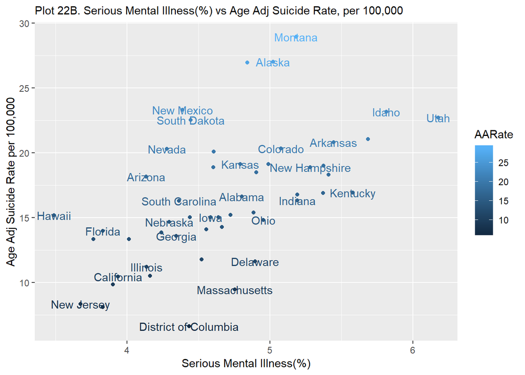

```r
ggplot(suic_cor, aes(SerMH*100,AARate, color = AARate)) + geom_point() + geom_text(aes(label=state), check_overlap = TRUE)+
  labs(subtitle="Plot 22B. Serious Mental Illness(%) vs Age Adj Suicide Rate, per 100,000", x="Serious Mental Illness(%)", y="Age Adj Suicide Rate per 100,000")
```

### 6.1.2 2017 State Suicide Rate by Gender, Age 15+ Only

We have a chance to compare suicide distribution based on gender.

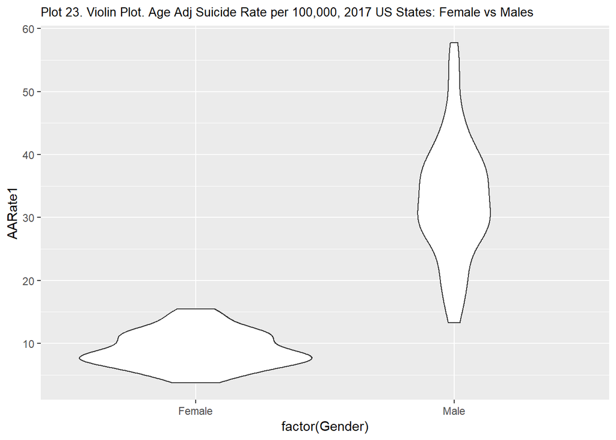

```r
state2017GA$AARate1<-(state2017GA$Age.Adjusted.Rate.Lower.95..Confidence.Interval+state2017GA$Age.Adjusted.Rate.Upper.95..Confidence.Interval)/2

state2017GA1<-filter(state2017GA,Gender!='')

p <- ggplot(state2017GA1, aes(factor(Gender), AARate1))

p + geom_violin()+ggtitle("Plot 23. Violin Plot. Age Adj Suicide Rate per 100,000, 2017 US States: Female vs Males")+theme(plot.title = element_text(size=10))
```

Interesting results. Female distribution has much more narrow range, while male one spreads over wider range.

Let’s see how male and female suicide rates correlate.

```r
state2017GA2<-state2017GA1%>%select(state,Gender,AARate1)%>%spread(Gender,AARate1)

cor(state2017GA2$Male, state2017GA2$Female)
```

```
## [1] 0.8955711
```

[figure not shown]

```r
scatterplot(state2017GA2$Male~state2017GA2$Female, xlab="Male suicide rate, Age Adj per 100,000", ylab="Female suicide rate, Age Adj , per 100,00", main="Plot 24. Male vs Female Suicide Rate, per 100,000")
```

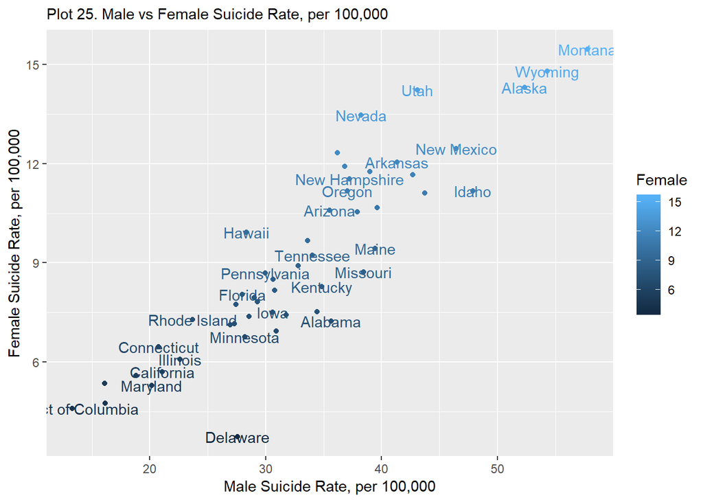

```r
ggplot(state2017GA2, aes(Male,Female, color = Female)) + geom_point() + geom_text(aes(label=state), check_overlap = TRUE)+
  labs(subtitle="Plot 25. Male vs Female Suicide Rate, per 100,000", x="Male Suicide Rate, per 100,000", y="Female Suicide Rate, per 100,000")
```

Now let’s run Male/Female data vs SAMHA tables to see if we get some meaningful results. state2017F

#### 6.1.2.1 Male Suicide Rates vs SAMHA Survey

Please remember that SAMHA data is not broken by gender. So, we are forced to compare male population to total.

Let’s check correlation between male suicide rate and other SAMHA’s variables:

Interestingly, that r for male suicide rate vs thoughts of suicide has dropped, but not by a lot. r=0.53. Modest correlation.

Vs Heroin Use - practically no correlation, r=-0.02

Vs Alcohol Use, Binge Drinking - week negative correlation(!), r=-0.24 and r=-0.22. Basically what we are seeing that higher alcohol consumption weakly predicts lower suicide rate. Not what I have expected.

Vs Painkillers Abuse - finally we got some decent correlation. r=0.46.

Vs Serious Mental Illness - bingo! r=0.59. Hard to believe but serious mental illness is a better predictor than serious thoughts of suicide.

```r
state2017MC<-select(state2017M,state, AARate)

suic_r_t_m<-merge(state2017MC, SAMHA_master, by = "state")

suic_r_t_m$state<-NULL

res <- cor(suic_r_t_m)

round(res, 2)%>%
  kable() %>%
  kable_styling()
```

|  | AARate | ThoughtSuic | SerMH | Painkillers | DrugNoM | DrugAny | Binge | DrugDis | AlcDis | AlcUse | Heroin | SubAbuse |
| --- | --- | --- | --- | --- | --- | --- | --- | --- | --- | --- | --- | --- |
| AARate | 1.00 | 0.53 | 0.59 | 0.46 | -0.19 | -0.03 | -0.22 | 0.02 | 0.07 | -0.24 | -0.02 | 0.02 |
| ThoughtSuic | 0.53 | 1.00 | 0.80 | 0.46 | 0.24 | 0.31 | -0.07 | 0.31 | 0.26 | -0.02 | 0.16 | 0.29 |
| SerMH | 0.59 | 0.80 | 1.00 | 0.78 | 0.18 | 0.18 | -0.21 | 0.26 | 0.13 | -0.25 | 0.24 | 0.18 |
| Painkillers | 0.46 | 0.46 | 0.78 | 1.00 | -0.01 | -0.05 | -0.29 | 0.13 | -0.13 | -0.35 | 0.24 | -0.03 |
| DrugNoM | -0.19 | 0.24 | 0.18 | -0.01 | 1.00 | 0.83 | 0.36 | 0.80 | 0.57 | 0.38 | 0.14 | 0.68 |
| DrugAny | -0.03 | 0.31 | 0.18 | -0.05 | 0.83 | 1.00 | 0.32 | 0.81 | 0.57 | 0.48 | 0.22 | 0.70 |
| Binge | -0.22 | -0.07 | -0.21 | -0.29 | 0.36 | 0.32 | 1.00 | 0.23 | 0.77 | 0.88 | 0.00 | 0.70 |
| DrugDis | 0.02 | 0.31 | 0.26 | 0.13 | 0.80 | 0.81 | 0.23 | 1.00 | 0.52 | 0.27 | 0.35 | 0.69 |
| AlcDis | 0.07 | 0.26 | 0.13 | -0.13 | 0.57 | 0.57 | 0.77 | 0.52 | 1.00 | 0.70 | 0.01 | 0.95 |
| AlcUse | -0.24 | -0.02 | -0.25 | -0.35 | 0.38 | 0.48 | 0.88 | 0.27 | 0.70 | 1.00 | 0.13 | 0.67 |
| Heroin | -0.02 | 0.16 | 0.24 | 0.24 | 0.14 | 0.22 | 0.00 | 0.35 | 0.01 | 0.13 | 1.00 | 0.13 |
| SubAbuse | 0.02 | 0.29 | 0.18 | -0.03 | 0.68 | 0.70 | 0.70 | 0.69 | 0.95 | 0.67 | 0.13 | 1.00 |

#### 6.1.2.2 Female Suicide Rates vs SAMHA Survey

Please remember that SAMHA data is not broken by gender. So, we are forced to compare female population to total.

Let’s check correlation between female suicide rate and other SAMHA’s variables:

Vs Drug Use, Any - practically no correlation, r=0.11

Vs Heroin Use - practically no correlation, r=-0.04

Vs Alcohol Use and Binge Drinking - week negative correlation, r=-0.19 and r=-0.18.

Vs Painkillers Abuse - finally we got some modest correlation. r=0.32.

Vs Serious Mental Illness - modest correlation, r=0.52. For females, thoughts of suicide is a slightly better predictor than serious mental illness.

```r
state2017FC<-select(state2017F,state, AARate1)

suic_corF<-merge(state2017FC, SAMHA_master, by = "state")

suic_corF$state<-NULL

res <- cor(suic_corF)

round(res, 2)%>%
  kable() %>%
  kable_styling()
```

|  | AARate1 | ThoughtSuic | SerMH | Painkillers | DrugNoM | DrugAny | Binge | DrugDis | AlcDis | AlcUse | Heroin | SubAbuse |
| --- | --- | --- | --- | --- | --- | --- | --- | --- | --- | --- | --- | --- |
| AARate1 | 1.00 | 0.57 | 0.52 | 0.32 | -0.04 | 0.11 | -0.18 | 0.13 | 0.14 | -0.19 | -0.04 | 0.08 |
| ThoughtSuic | 0.57 | 1.00 | 0.80 | 0.46 | 0.24 | 0.31 | -0.07 | 0.31 | 0.26 | -0.02 | 0.16 | 0.29 |
| SerMH | 0.52 | 0.80 | 1.00 | 0.78 | 0.18 | 0.18 | -0.21 | 0.26 | 0.13 | -0.25 | 0.24 | 0.18 |
| Painkillers | 0.32 | 0.46 | 0.78 | 1.00 | -0.01 | -0.05 | -0.29 | 0.13 | -0.13 | -0.35 | 0.24 | -0.03 |
| DrugNoM | -0.04 | 0.24 | 0.18 | -0.01 | 1.00 | 0.83 | 0.36 | 0.80 | 0.57 | 0.38 | 0.14 | 0.68 |
| DrugAny | 0.11 | 0.31 | 0.18 | -0.05 | 0.83 | 1.00 | 0.32 | 0.81 | 0.57 | 0.48 | 0.22 | 0.70 |
| Binge | -0.18 | -0.07 | -0.21 | -0.29 | 0.36 | 0.32 | 1.00 | 0.23 | 0.77 | 0.88 | 0.00 | 0.70 |
| DrugDis | 0.13 | 0.31 | 0.26 | 0.13 | 0.80 | 0.81 | 0.23 | 1.00 | 0.52 | 0.27 | 0.35 | 0.69 |
| AlcDis | 0.14 | 0.26 | 0.13 | -0.13 | 0.57 | 0.57 | 0.77 | 0.52 | 1.00 | 0.70 | 0.01 | 0.95 |
| AlcUse | -0.19 | -0.02 | -0.25 | -0.35 | 0.38 | 0.48 | 0.88 | 0.27 | 0.70 | 1.00 | 0.13 | 0.67 |
| Heroin | -0.04 | 0.16 | 0.24 | 0.24 | 0.14 | 0.22 | 0.00 | 0.35 | 0.01 | 0.13 | 1.00 | 0.13 |
| SubAbuse | 0.08 | 0.29 | 0.18 | -0.03 | 0.68 | 0.70 | 0.70 | 0.69 | 0.95 | 0.67 | 0.13 | 1.00 |

### 6.1.3 Study: Colorado vs Minnesota. Where does the difference come from?

Our main research is to understand why such a gap is there. Our collected results should give us final ideas on why we have such a big discrepancy in suicide rates. I have mentioned DC and Montana in the introduction. These 2 states lay on opposite ends of suicide rates; however, comparing these two states is as hard as it gets. Everything is different about them. One is in the Metro area, and another is rural state. Climate is so different, as well as ethnic distribution. Another problem, both states have low population rates. We are facing a typical “apple vs orange” problem. My goal is to find close populations to compare and show if population size plays a significant role in suicide rates. After looking at different factors I decided to compare Colorado and Minnesota. They have comparable population sizes, similar ethic distribution making them both well to do states; however, their suicide rates are significantly different. Minnesota is on the lower end with 13.8 and Colorado is on the higher end with 20.3. Colorado is 47% higher. It does not make any sense to me. Interestingly, later in the project I try to cluster states by SAMHA survey and Minnesota does come out as a state with not a lot of drug, alcohol, and mental health issues, while Colorado falls in mix bag category with some good and some bad indicators. Looking at the details, we can see that Colorado has much higher drug usage than Minnesota. Heroin use is the same for both states (low). Colorado also has higher rate of painkiller abuse, alcohol abuse, suicide thoughts, and mental illness. So, maybe we do have reasons. Let’s look at the data.

```r
col_min<-merge(state15_17C, state15_17M,by=c("Gender","X2013.Urbanization","Race","Hispanic.Origin"))

col_min$ratio<-col_min$AARate.x/col_min$AARate.y

arrange(col_min,desc(ratio))
```

[output not shown]

We can see that 3 populations got over twice as high rate in Colorado vs Minnesota. All their rates are considered reliable by CDC.

We will focus on these 3 groups:

```r
col_min1<-merge(state08_17C, state08_17M,by=c("Gender","X2013.Urbanization","Race","ICD.10.113.Cause.List"))

col_min1$ratio<-col_min1$AARate.x/col_min1$AARate.y

col_min_C1<-filter(col_min1,Gender=='Male',Race=='Black or African American',X2013.Urbanization=='Large Central Metro')

head(arrange(col_min_C1,desc(ratio)))
```

[output not shown]

For our first group we can see that Transport accidents and Alcoholic liver disease are very high for Colorado. Let’s see if these diseases would correlate for other states.

```r
col_min_C2<-filter(col_min1,Gender=='Male',Race=='White',X2013.Urbanization=='Small Metro')

head(arrange(col_min_C2,desc(ratio)))
```

[output not shown]

For our second group we can see that Assault, HIV, and Accidental poisoning are very high for Colorado. Let’s see if these diseases would correlate for other states.

```r
col_min_C3<-filter(col_min1,Gender=='Female',Race=='White',X2013.Urbanization=='Small Metro')

arrange(col_min_C3,desc(ratio))
```

[output not shown]

For our third group we can see that Assault, Viral hepatitis, and Accidental poisoning are very high for Colorado. Let’s see if these diseases would correlate for other states.

## 6.2 SAMHA State Prevalaince of Drug and Alcohol Use and Mental Issues Data.

### 6.2.1 Younger vs older population with thoughts of suicide

Correlation between younger and older population with thoughts of suicide by state approaching so called strong correlation (r=0.66).

```r
cor(suicide_tt1$Y18_25, suicide_tt1$Y26P)
```

```
## [1] 0.6594445
```

[figure not shown]

```r
scatterplot(suicide_tt1$Y18_25*100~suicide_tt1$Y26P,xlab="Age 18-25, %", ylab="Age 26+, %", main="Plot 26. Serious Thoughts of Suicide, rate(%): 18-25 years old vs 26+ years old cohort")
```

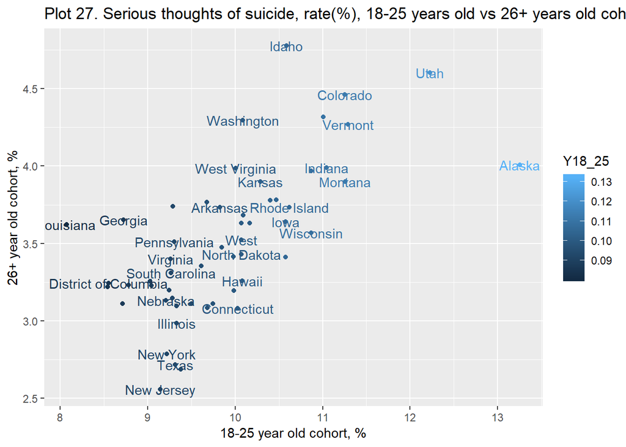

```r
ggplot(suicide_tt1, aes(Y18_25*100,Y26P*100, color = Y18_25)) + geom_point() + geom_text(aes(label=state), check_overlap = TRUE)+ ggtitle("Plot 27. Serious thoughts of suicide, rate(%), 18-25 years old vs 26+ years old cohort")+labs(x = "18-25 year old cohort, %", y = "26+ year old cohort, %")
```

### 6.2.2 Thoughts of suicide vs Any Mental Illness

Correlation between population with thoughts of suicide and one with any mental illness by state is strong (r=0.74).

```r
suic_amh<-merge(suicide_tt1, amh_dt, by = "state")

cor(suic_amh$Y18P.x, suic_amh$Y18P.y)
```

```
## [1] 0.7351503
```

[figure not shown]

```r
suic_amh$temp<-suic_amh$Y18P.x*100

suic_amh$temp1<-suic_amh$Y18P.y*100

scatterplot(suic_amh$temp~suic_amh$temp1,xlab="Thoughts of suicide, %", ylab="Any Mental Illness, %", main="Plot 27A. Thoughts of Suicide vs Any Mental Illness, %")
```

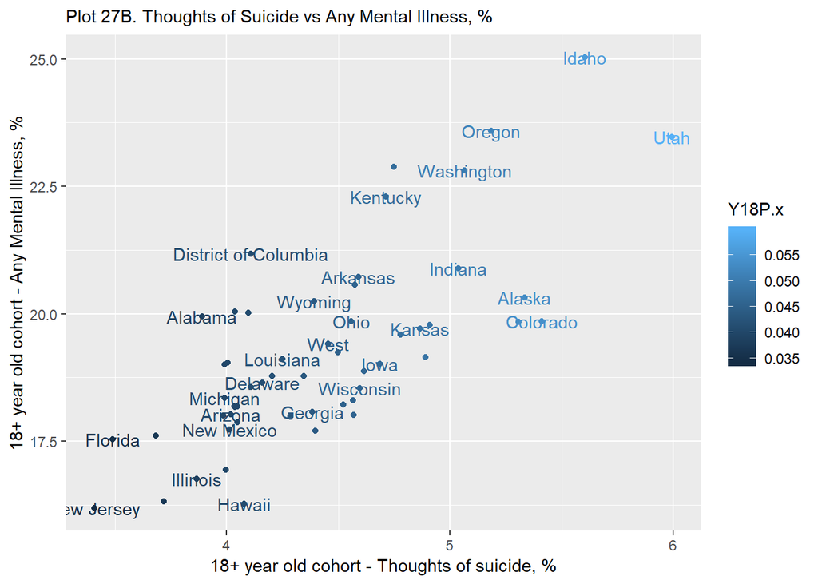

```r
ggplot(suic_amh, aes(temp,temp1, color = Y18P.x)) + geom_point() + geom_text(aes(label=state), check_overlap = TRUE)+
  labs(subtitle="Plot 27B. Thoughts of Suicide vs Any Mental Illness, %")+labs(x = "18+ year old cohort - Thoughts of suicide, %", y = "18+ year old cohort - Any Mental Illness, %")
```